# AI Studios

## Stroke Prediction

### Binary Classification Task Using Testlin Machine

#### By: Pritika Timsina (GH1017979)

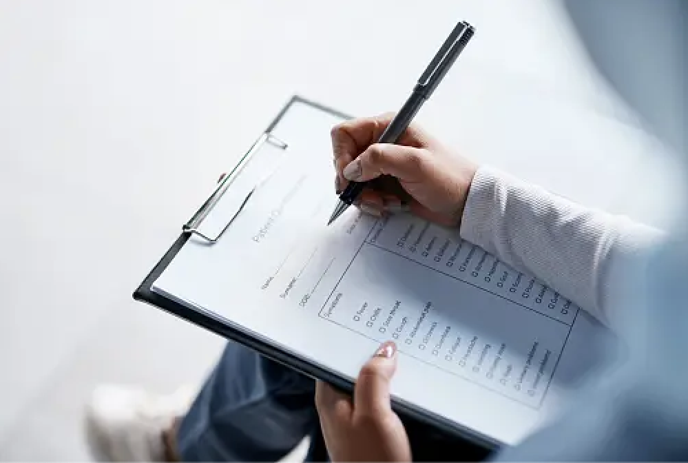

```python
image_path = "hospital.png"
display(Image(filename=image_path))
```

#### 1. Introduction

#### 2. Business Question

#### 3. About the dataset

##### i. Column Description

#### 4. Loading the dataset

#### 5. EDA and Data Processing

##### i. Insights from the steps done for EDA

##### ii. Findings

#### 6. Data Visualisation

##### i. Findings

#### 7. Feature Engineering

#### 8. Tsetlin Machine

##### i. Tsetlin Machine with Genetic Algorithm

##### ii. Findings

#### 9. Other Algoritm Models

##### i. Findings.

#### 10. Algoritm Model Comparison

#### 11. Conclusion

#### 12. Refrences

#### 13. Assessment Submission Form

## Introduction

#### In this project I will be working as a data scientist in a hospital and will be using Binary Classification Task Using Testlin Machine. For my project I will be using AI predictive Models to compare their performance against the Testlin Machine.

### Business Question

#### Are patients at high risk of stroke based on their data provided in the hospital?

## About the dataset

#### The dataset can be accessed from the following link: https://www.kaggle.com/datasets/fedesoriano/stroke-prediction-dataset. This dataset also contains 3 bianry columns which makes it better for the project.

#### Storke dataset is used in this project is gathered from Kaggle, its linked with the chances of stroke in patients. The dataset has non numerical columns like gender, heart diseases, martial status, work, residence, smoking status and numerical columns like id, age, hypertension, heart disease, glucose level, bmi and stroke.

### Column Description

#### 1. id: Unique identifier given to each patient at the hospital

#### 2. gender: the gender of the patient

#### 3. age: Age of different patients at the hospital

#### 4. hypertension: denotes if a patient has high blood pressure or not (0: no, 1: yes)

#### 5. heart_diesase: denotes if a patient ever had heart disease or not (0: no, 1: yes)

#### 6. ever_married: martial status of a patient

#### 7. work_type: Description of patients work status

#### 8. Residence_type: Describes the type of neighbourhood the patient lives in

#### 9. avg_glucose_level: Sugar concentration in a patients body

#### 10. bmi: indicates the body mass index of a patient (a person's weight divided by their height)

#### 11. smoking_status: describes if a person has ever smoked or not

#### 12. stoke: defines if a person ever had a stroke before (0: no, 1: yes)

## Importing Libraries

```python
!pip install pyTsetlinMachine
!pip install deap
```

```python
# For the dataset and python process

import numpy as np
import pandas as pd

# For loading the images

from IPython.display import Image
from IPython.display import display

# For visualisation

import matplotlib.pyplot as plt
import seaborn as sns

# Feature Engineering

from sklearn.compose import ColumnTransformer
from sklearn.pipeline import Pipeline
from sklearn.preprocessing import OneHotEncoder
from sklearn.preprocessing import LabelEncoder
from sklearn.preprocessing import StandardScaler

# For Warnings

import warnings

#Tsetlin Machine

from sklearn.model_selection import train_test_split
from pyTsetlinMachine.tm import MultiClassTsetlinMachine
from sklearn.metrics import classification_report
from sklearn.metrics import confusion_matrix
import random
from deap import base, creator, tools, algorithms
from sklearn.metrics import accuracy_score
import multiprocessing
from imblearn.over_sampling import SMOTE
from sklearn.model_selection import train_test_split
import numpy as np
from sklearn.metrics import recall_score
from sklearn.utils import check_random_state
from sklearn.utils import check_X_y
from sklearn.utils import column_or_1d
from sklearn.utils import check_array


# Algorithms

from sklearn.preprocessing import StandardScaler
from sklearn.metrics import confusion_matrix, accuracy_score, precision_score, recall_score, f1_score
from sklearn.linear_model import LogisticRegression
from sklearn.ensemble import RandomForestClassifier
from sklearn.svm import SVC
from sklearn.ensemble import GradientBoostingClassifier
```

## Loading the dataset

```python
dataset = pd.read_csv('stroke 2.csv')
display(dataset)
```

|  | id | gender | age | hypertension | heart_disease | ever_married | work_type | Residence_type | avg_glucose_level | bmi | smoking_status | stroke |
| --- | --- | --- | --- | --- | --- | --- | --- | --- | --- | --- | --- | --- |
| 0 | 9046 | Male | 67.0 | 0 | 1 | Yes | Private | Urban | 228.69 | 36.6 | formerly smoked | 1 |
| 1 | 51676 | Female | 61.0 | 0 | 0 | Yes | Self-employed | Rural | 202.21 | NaN | never smoked | 1 |
| 2 | 31112 | Male | 80.0 | 0 | 1 | Yes | Private | Rural | 105.92 | 32.5 | never smoked | 1 |
| 3 | 60182 | Female | 49.0 | 0 | 0 | Yes | Private | Urban | 171.23 | 34.4 | smokes | 1 |
| 4 | 1665 | Female | 79.0 | 1 | 0 | Yes | Self-employed | Rural | 174.12 | 24.0 | never smoked | 1 |
| ... | ... | ... | ... | ... | ... | ... | ... | ... | ... | ... | ... | ... |
| 5105 | 18234 | Female | 80.0 | 1 | 0 | Yes | Private | Urban | 83.75 | NaN | never smoked | 0 |
| 5106 | 44873 | Female | 81.0 | 0 | 0 | Yes | Self-employed | Urban | 125.20 | 40.0 | never smoked | 0 |
| 5107 | 19723 | Female | 35.0 | 0 | 0 | Yes | Self-employed | Rural | 82.99 | 30.6 | never smoked | 0 |
| 5108 | 37544 | Male | 51.0 | 0 | 0 | Yes | Private | Rural | 166.29 | 25.6 | formerly smoked | 0 |
| 5109 | 44679 | Female | 44.0 | 0 | 0 | Yes | Govt_job | Urban | 85.28 | 26.2 | Unknown | 0 |

5110 rows × 12 columns

```python
dataset.shape
```

```
(5110, 12)
```

```python
dataset.columns
```

```
Index(['id', 'gender', 'age', 'hypertension', 'heart_disease', 'ever_married',
       'work_type', 'Residence_type', 'avg_glucose_level', 'bmi',
       'smoking_status', 'stroke'],
      dtype='object')
```

## EDA and Data Preprocessing

#### EDA (Exploratory Data Analysis) is the process where the dataset is cleaned by handling the null, missing and duplicate values. The quality of the dataset will be insured for further analysis.

### Insights from the steps done for EDA are:

#### 1. Data Cleaning: While handling the missing values in the columns, I found that column BMI has some NaN values and replacing those values with the average values from the column.

#### 2. Duplicates: Checking if the id's are different for all patients so that there wont be any duplicates during future use.

#### 3. Categorical datas: Before Converting Categorical Data into Numerical Data I checked the columns with categorical data and the number of catergorical values in those columns.

### Findings

#### After cleaning EDA process I realized that the stroke dataset had NaN values in bmi column and I adjusted that by replacing the NaN values with the average values in column. There are no duplicated values in my dataset. However, there are some categorical dataset that needs to be changed to numerical columns and some columns needs to be binarized which will be done in the Feature Engineering part.

```python
# Checking the missing values

dataset.isnull().sum()
```

```
id                     0
gender                 0
age                    0
hypertension           0
heart_disease          0
ever_married           0
work_type              0
Residence_type         0
avg_glucose_level      0
bmi                  201
smoking_status         0
stroke                 0
dtype: int64
```

```python
bmi_column = dataset['bmi']
print(bmi_column)
```

```
0       36.6
1        NaN
2       32.5
3       34.4
4       24.0
        ...
5105     NaN
5106    40.0
5107    30.6
5108    25.6
5109    26.2
Name: bmi, Length: 5110, dtype: float64
```

```python
# In the dataset BMI has some nan values. So handle the missing values first.
# To fill in the missing values by calculating the average value and then filling in those in place of missing values.

mean_bmi = dataset['bmi'].mean()
dataset['bmi'].fillna(mean_bmi, inplace=True)
```

```python
# Checking for duplicate id to ensure that all the patient have different patient ids

duplicate_id = dataset[dataset.duplicated(subset=['id'], keep=False)]

if not duplicate_id.empty:
    print("There are the duplicate rows:")
    print(duplicate_id)

else:

    print("All patients have unique IDs.")
```

```
All patients have unique IDs.
```

```python
# Checking for the categorical datas

for column in dataset.columns:

    if dataset[column].dtype == 'object':
        print(f'\tColumn: {column}\n')
        print(dataset[column].value_counts(),'\n')
        print('-' * 50)
```

```
	Column: gender

Female    2994
Male      2115
Other        1
Name: gender, dtype: int64

--------------------------------------------------
	Column: ever_married

Yes    3353
No     1757
Name: ever_married, dtype: int64

--------------------------------------------------
	Column: work_type

Private          2925
Self-employed     819
children          687
Govt_job          657
Never_worked       22
Name: work_type, dtype: int64

--------------------------------------------------
	Column: Residence_type

Urban    2596
Rural    2514
Name: Residence_type, dtype: int64

--------------------------------------------------
	Column: smoking_status

never smoked       1892
Unknown            1544
formerly smoked     885
smokes              789
Name: smoking_status, dtype: int64

--------------------------------------------------
```

```python
bmi_columnnew = dataset['bmi']
print(bmi_columnnew)
```

```
0       36.600000
1       28.893237
2       32.500000
3       34.400000
4       24.000000
          ...
5105    28.893237
5106    40.000000
5107    30.600000
5108    25.600000
5109    26.200000
Name: bmi, Length: 5110, dtype: float64
```

```python
dataset.isnull().sum()
```

```
id                   0
gender               0
age                  0
hypertension         0
heart_disease        0
ever_married         0
work_type            0
Residence_type       0
avg_glucose_level    0
bmi                  0
smoking_status       0
stroke               0
dtype: int64
```

## Data Visualisation

#### Perfoming visual analysis as a part of EDA to find more insights about my dataset based on different criterias to make analysis more easier and accurate. I also used .describe() code to get the descriptive statistical summary of the dataset for more insights.

#### I used Matplot library and Sea born and made pie chart to first find the distribution of patients who has stroke and later I also implemented KDE (Kernal Density Estimation) to figure out the distribution of the of the numerical columns and histograms to show the distribution of stroke based on how categorical datasets affected the stoke.

### Findings:

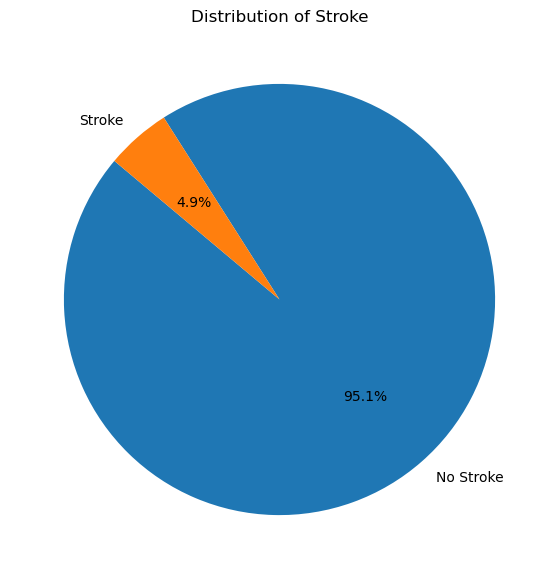

```python
# Distribution of Storke in patients as of now

stroke_counts = dataset['stroke'].value_counts()

# Create a pie chart
plt.figure(figsize=(7, 7))
plt.pie(stroke_counts, labels=['No Stroke', 'Stroke'], autopct='%1.1f%%', startangle=140)
plt.title("Distribution of Stroke")
plt.show()
```

```
               age  hypertension  heart_disease  avg_glucose_level  \
count  5110.000000   5110.000000    5110.000000        5110.000000
mean     43.226614      0.097456       0.054012         106.147677
std      22.612647      0.296607       0.226063          45.283560
min       0.080000      0.000000       0.000000          55.120000
25%      25.000000      0.000000       0.000000          77.245000
50%      45.000000      0.000000       0.000000          91.885000
75%      61.000000      0.000000       0.000000         114.090000
max      82.000000      1.000000       1.000000         271.740000

               bmi
count  5110.000000
mean     28.893237
std       7.698018
min      10.300000
25%      23.800000
50%      28.400000
75%      32.800000
max      97.600000
```

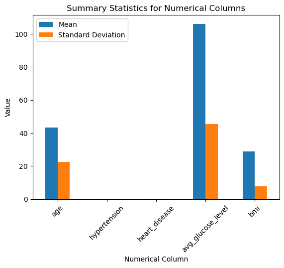

```python
# Statistical Insights

numericals = ['age', 'hypertension', 'heart_disease', 'avg_glucose_level', 'bmi']
summary = dataset[numericals].describe()
print(summary)

# Visual

summary = summary.transpose()
plt.figure(figsize=(10, 6))
summary.plot(kind='bar', y=['mean', 'std'], stacked=False)
plt.title("Summary Statistics for Numerical Columns")
plt.xlabel("Numerical Column")
plt.ylabel("Value")
plt.xticks(rotation=45)
plt.legend(["Mean", "Standard Deviation"])
plt.show()
```

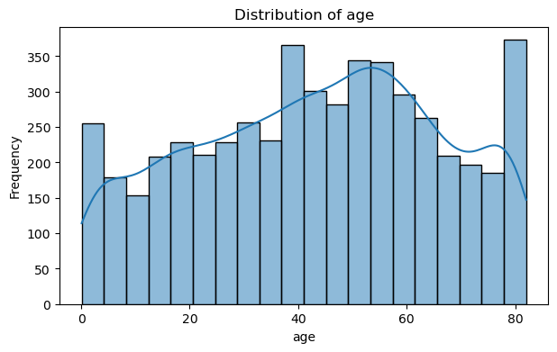

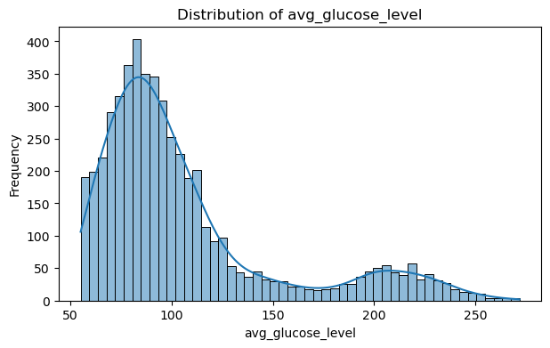

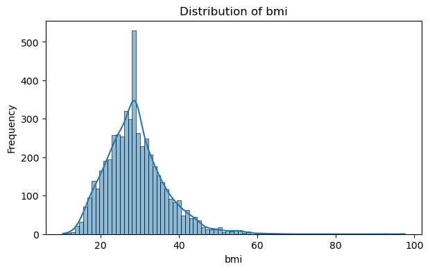

```python
# KDE analysis

numericals = ['age', 'avg_glucose_level', 'bmi']

for columns in numericals:
    plt.figure(figsize=(7, 4))
    sns.histplot(dataset[columns], kde=True)
    plt.title(f"Distribution of {columns}")
    plt.xlabel(columns)
    plt.ylabel("Frequency")
    plt.show()
```

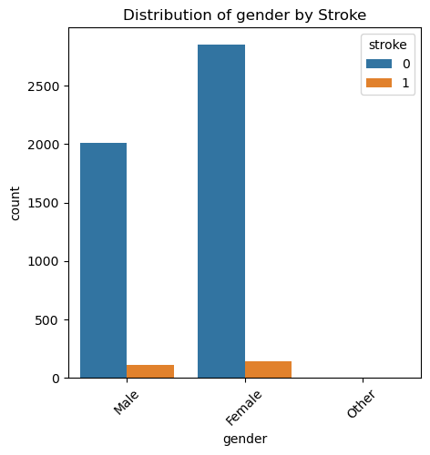

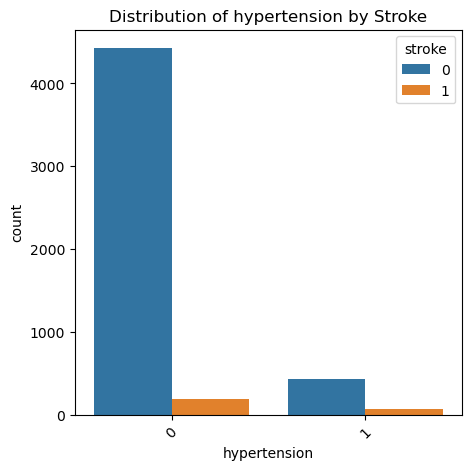

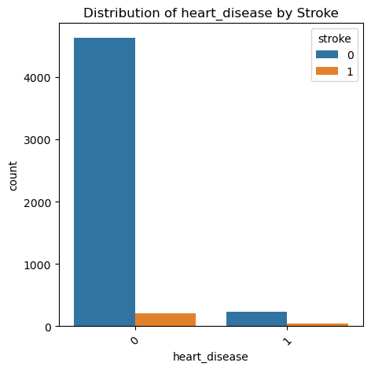

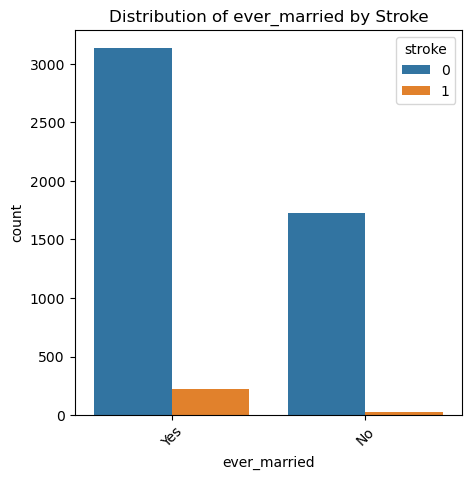

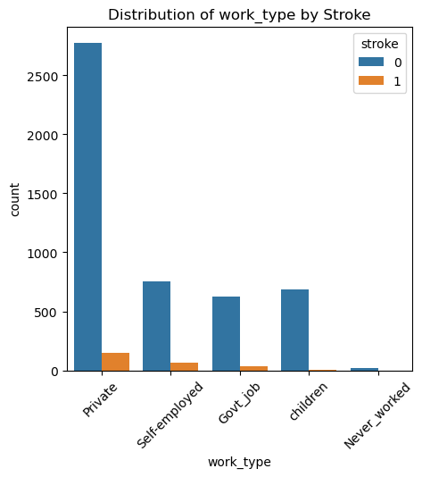

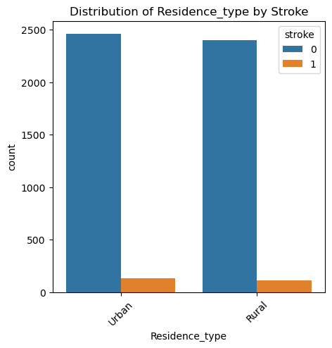

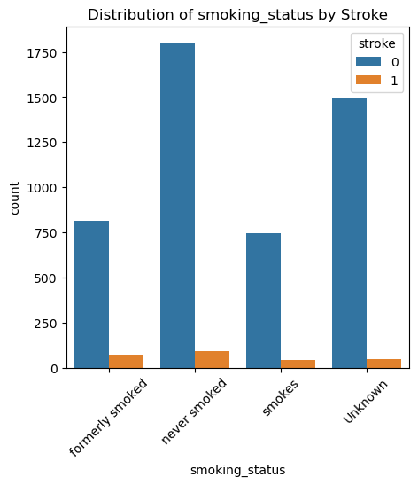

```python
# based on Categorical columns

categorical_cols= ['gender', 'hypertension', 'heart_disease', 'ever_married', 'work_type', 'Residence_type', 'smoking_status']

for column in categorical_cols:
    plt.figure(figsize=(5, 5))
    sns.countplot(data=dataset, x=column, hue='stroke')
    plt.title(f"Distribution of {column} by Stroke")
    plt.xticks(rotation=45)
    plt.show()
```

## Feature Engineering

#### For the Feature Engineering step the approches taken into consideration are One hot encoding categorical data

#### One Hot Encoding: One hot encoding is a process to transform categorical data into numerical data. It is a feature in scikit learn. It basically creates a binary column for each category which was originally a string.

#### Correlation Matrix: The corrleation matrix helps us to know which features are most to least correlated with the target which is stroke for this case. So age has a positive correlation where as work type children has a negative correlation with stroke

```python
# One hot Encoding

categorical_cols = ['gender', 'ever_married','work_type', 'Residence_type', 'smoking_status']

# To avoid Warnings
warnings.simplefilter(action='ignore', category=FutureWarning)

encoding = OneHotEncoder(drop='first', sparse_output=False)
encoded = encoding.fit_transform(dataset[categorical_cols])
encoded_column = encoding.get_feature_names_out(input_features=categorical_cols)
dataset[encoded_column] = encoded

print(dataset[encoded_column].head(3))
```

```
   gender_Male  gender_Other  ever_married_Yes  work_type_Never_worked  \
0          1.0           0.0               1.0                     0.0
1          0.0           0.0               1.0                     0.0
2          1.0           0.0               1.0                     0.0

   work_type_Private  work_type_Self-employed  work_type_children  \
0                1.0                      0.0                 0.0
1                0.0                      1.0                 0.0
2                1.0                      0.0                 0.0

   Residence_type_Urban  smoking_status_formerly smoked  \
0                   1.0                             1.0
1                   0.0                             0.0
2                   0.0                             0.0

   smoking_status_never smoked  smoking_status_smokes
0                          0.0                    0.0
1                          1.0                    0.0
2                          1.0                    0.0
```

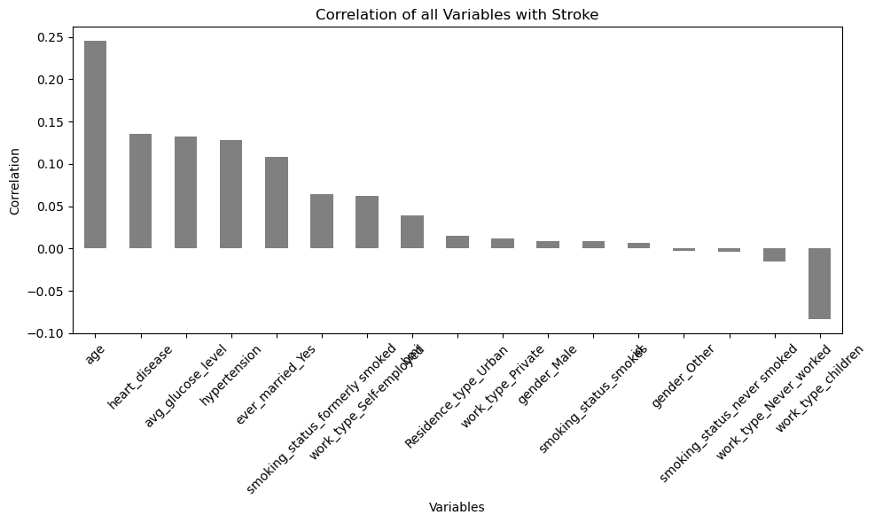

```python
# correlation matrix

correlation_matrix = dataset.corr()
target = correlation_matrix['stroke'].sort_values(ascending=False)

plt.figure(figsize=(10, 6))
target.drop('stroke').plot(kind='bar', color='grey')
plt.title("Correlation of all Variables with Stroke")
plt.xlabel("Variables")
plt.ylabel("Correlation")
plt.xticks(rotation=45)
plt.tight_layout()
plt.show()
```

## Tsetlin Machine

#### - Setting two categories X any y where X is the Supporting variable and y is the target Varibale

#### - Splitting the data into train and test sets.

#### - Setting the hyperparameters for the Tsetlin Machine

#### - Evaluating the predictions and accuracy score

#### - Visualising a confusion matrix

### Tsetlin Machine with Genetic Algorithm

#### - Performing smote to balance the data in each varibale for generic algorithm

#### - Graphing the learning Curve

#### - Implementing Generic Algorithm to get the selected features

### Findings

```python
# Setting the X and y value for Prediction

X = dataset.drop(columns=['stroke'])
y = dataset['stroke']
```

```python
# Splitting the data into X train Y train and X test and Y test sets

X_train, X_test, y_train, y_test = train_test_split(X, y, test_size=0.2, random_state=45)
```

```python
# List of categorical features without 'gender'
categorical_features = ['ever_married', 'work_type', 'Residence_type', 'smoking_status']

# Encoding the X-train and X-test with updated categorical_features list
X_train_encoded = pd.get_dummies(X_train, columns=gender)
X_test_encoded = pd.get_dummies(X_test, columns=gender)
```

```python
# hyperparameter tuning

number_clauses = 200  # Number of clauses for Tsetlin machine
number_iterations = 1000  # Number of iterations
t = 3.0  # Creating threshold
T = 15

tsetlin = MultiClassTsetlinMachine(number_clauses, number_iterations, t, T)
```

```python
tsetlin.fit(X_train_encoded.values, y_train.values)
```

```python
# Evaluation

y_prediction = tsetlin.predict(X_test_encoded.values)
accuracy = (y_prediction == y_test.values).mean()
precision = precision_score(y_test, y_prediction)
recall = recall_score(y_test, y_prediction)
f1 = f1_score(y_test, y_prediction)
```

```python
accuracy = (y_prediction == y_test.values).mean()
precision = precision_score(y_test, y_prediction)
recall = recall_score(y_test, y_prediction)
f1 = f1_score(y_test, y_prediction)
```

```python
print(f"Accuracy: {accuracy:.4f}")
print(f"Precision: {precision:.4f}")
print(f"Recall: {recall:.4f}")
print(f"F1-Score: {f1:.4f}")

# Print classification report
print(classification_report(y_test, y_prediction))
```

```
Accuracy: 0.1918
Precision: 0.0444
Recall: 0.8261
F1-Score: 0.0843
              precision    recall  f1-score   support

           0       0.95      0.16      0.28       976
           1       0.04      0.83      0.08        46

    accuracy                           0.19      1022
   macro avg       0.50      0.49      0.18      1022
weighted avg       0.91      0.19      0.27      1022
```

```
Confusion Matrix:
[[ 48 928]
 [  0  46]]
```

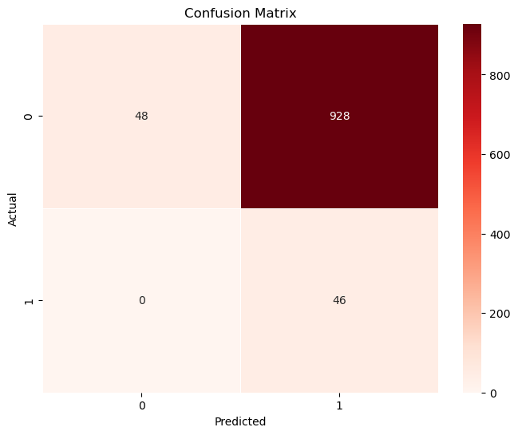

```python
# Confusion matrix

conf_matrix = confusion_matrix(y_test, y_prediction)

print("Confusion Matrix:")
print(conf_matrix)

plt.figure(figsize=(8, 6))
sns.heatmap(conf_matrix, annot=True, fmt="d", cmap="Reds", linewidths=.5)
plt.xlabel("Predicted")
plt.ylabel("Actual")
plt.title("Confusion Matrix")
plt.show()
```

```python
# Smote to balance the data

smote = SMOTE(random_state=42)
X_train_balanced, y_train_balanced = smote.fit_resample(X_train_encoded, y_train)
```

```python
tsetlin.fit(X_train_balanced, y_train_balanced)
```

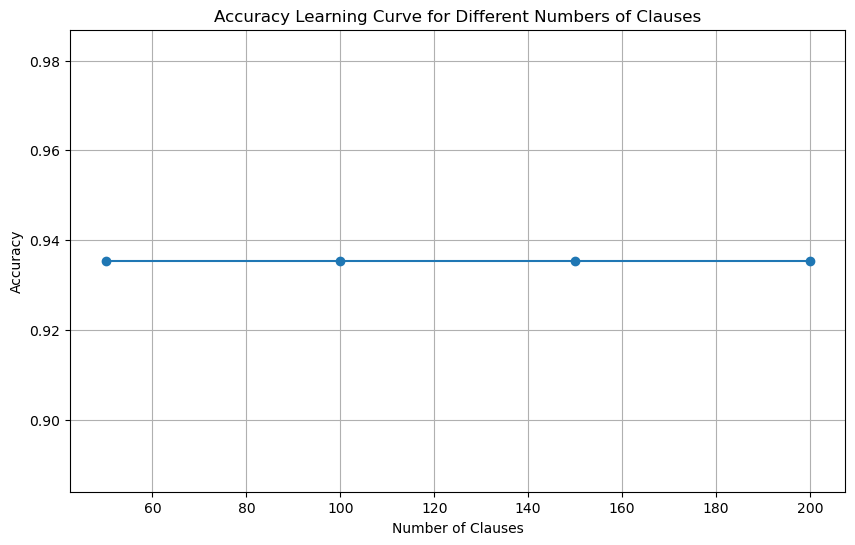

```python
# Defining a smaller range of clause

clause_values = [50, 100, 150, 200]

accuracy_values = []

for num_clauses in clause_values:

    tsetlin = MultiClassTsetlinMachine(num_clauses, 500, t, T)
    tsetlin.fit(X_train_balanced, y_train_balanced)
    y_pred = tsetlin.predict(X_test_encoded)
    accuracy = (y_pred == y_test.values).mean()

    accuracy_values.append(accuracy)
plt.figure(figsize=(10, 6))
plt.plot(clause_values, accuracy_values, marker='o')

plt.title("Accuracy Learning Curve for Different Numbers of Clauses")
plt.xlabel("Number of Clauses")
plt.ylabel("Accuracy")
plt.grid(True)
plt.show()
```

```python
# Implementing Generic Algorithm

# fitness function
def fitness_function(features, X, y):

    selected_features = X[:, features]
    X_train, X_test, y_train, y_test = train_test_split(selected_features, y, test_size=0.2, random_state=42)
    scaler = StandardScaler()
    X_train = scaler.fit_transform(X_train)
    X_test = scaler.transform(X_test)
    tm = MultiClassTsetlinMachine(number_of_clauses=250, T=100, s=8.0)
    tm.fit(X_train, y_train, epochs=6)
    y_pred = tm.predict(X_test)
    fitness_score = recall_score(y_test, y_pred, average='weighted')
    return fitness_score

# Genetic Algorithm

def GA(X, y, population_size=20, num_generations=100, mutation_rate=0.15, feature_number=10, early_stopping_generations=20):
    X, y = check_X_y(X, y, accept_sparse=False, force_all_finite=False)
    random_state = check_random_state(None)

    population = [random.sample(range(X.shape[1]), feature_number) for _ in range(population_size)]
    best_fitness = 0

    generations_without_improvement = 0
    for generation in range(num_generations):
        scores = [fitness_function(features, X, y) for features in population]
        fitness_scores = [score for score in scores]
        current_best_fitness = max(fitness_scores)

        if current_best_fitness > best_fitness:
            best_fitness = current_best_fitness
            generations_without_improvement = 0

        else:
            generations_without_improvement += 1

        if generations_without_improvement >= early_stopping_generations:
            print("Early stopping: No improvement in fitness for the last {} generations.".format(early_stopping_generations))
            break
        num_parents = int(population_size / 2)
        parents = np.argsort(fitness_scores)[-num_parents:].tolist()
        new_population = []

        while len(new_population) < population_size:
            parent1, parent2 = random.sample(parents, 2)
            crossover_point = random.randint(1, feature_number - 1)
            child = population[parent1][:crossover_point] + population[parent2][crossover_point:]
            if random.random() < mutation_rate:
                gene_to_mutate = random.randint(0, feature_number - 1)
                child[gene_to_mutate] = random.randint(0, X.shape[1] - 1)

            new_population.append(child)

        population = new_population

    best_idx = np.argmax(fitness_scores)
    best_individual = population[best_idx]

    best_features = np.array(best_individual)
    selected_features = X[:, best_features]

    tm = MultiClassTsetlinMachine(number_of_clauses=250, T=100, s=8.0)
    tm.fit(selected_features, y)

    return best_individual, tm

best_individual, best_tm = GA(X_train_encoded, y_train, population_size=20, num_generations=2, mutation_rate=0.15, feature_number=10, early_stopping_generations=20)

print("\nSelected Features:")
print(best_individual)
```

```
Selected Features:
[19, 17, 3, 30, 38, 15, 6, 17, 31, 23]
```

## Algorithm Models

#### Random Forest, Logistic Regression, SVM and Gradient boosting classifier to comapre with my testlin machine prediction.

#### - First we implemented the algorithms

#### - then fitted it to the train and test sets

#### - then defined a evaluation metrics to make evaluation process easier.

#### -Finally, printed the output and along with the results of each model along with confusion matrix

### Findings

#### Accuracy: Accuracy helps too know how many predictions are correct out of the tota prediction. All four algorithms have 94% accuracy, which is really good.

#### Precision: This measure helps to find the proportion of true-positive predictions. In this case Random Forset and SVM have 0 a precision value.

```python
# Implementing Rnadom Forest Classifier, Logisitic Regression, Support Vector Classifier and
# Gradient Boosting Classifier

rf_model = RandomForestClassifier()
lr_model = LogisticRegression()
lr_model = LogisticRegression(max_iter=1000)
svm_model = SVC()
gb_model = GradientBoostingClassifier()

# Fitting Train and Test
rf_model.fit(X_train_encoded, y_train)
lr_model.fit(X_train_encoded, y_train)
svm_model.fit(X_train_encoded, y_train)
gb_model.fit(X_train_encoded, y_train)
```

[output not shown]

[figure not shown]

[output not shown]

[figure not shown]

[output not shown]

[figure not shown]

[output not shown]

[figure not shown]

```python
# Defining a function to evaluate each model and print thier metrics and confusion matrix

def evaluate_model(model, X_test_encoded, y_test):
    y_pred = model.predict(X_test_encoded)
    accuracy = accuracy_score(y_test, y_pred)
    precision = precision_score(y_test, y_pred)
    recall = recall_score(y_test, y_pred)
    f1 = f1_score(y_test, y_pred)

    print(f"Accuracy: {accuracy}")
    print(f"Precision: {precision}")
    print(f"Recall: {recall}")
    print(f"F1-Score: {f1}")

# Confusion Matrix
    cm = confusion_matrix(y_test, y_pred)

    plt.figure(figsize=(8, 6))
    sns.heatmap(cm, annot=True, fmt="d", cmap="Blues", cbar=False)
    plt.xlabel("Predicted")
    plt.ylabel("Actual")
    plt.title("Confusion Matrix")
    plt.show()

# Evaluating models
print("Random Forest:")
evaluate_model(rf_model, X_test_encoded, y_test)

print("\nLogistic Regression:")
evaluate_model(lr_model, X_test_encoded, y_test)

print("\nSupport Vector Machine:")
evaluate_model(svm_model, X_test_encoded, y_test)

print("\nGradient Boosting:")
evaluate_model(gb_model, X_test_encoded, y_test)
```

## Algorithm model Comparisons

#### For my project I used different machine learning algorithms in my project, the Algorithms I used are:

#### 1. Tsetlin Machine

#### 2. Random Forest

#### 3. Logisitic Regression

#### 4. SVM (Support Vector Machine)

#### 5. Gradient Boosting Classifier

#### I used these algorithms to make a model that could predict if patients are at high risk of stroke or not based on their datas provided to the hospital.

#### For the tsetlin machine algorithm after performing the necessary steps and training and evaluating the model's accuracy, precision, recall F1-score and confusion matrix the findings were:

#### The model wasn't very accurate since the accuracy score is just 19.18 %, hence the model will not provide accurate predictions.

#### Precision score was 4.44% for class 1 which indicated that out of all the predictions made only a very small proportion of positive predictions were true.

#### The recall for class 1 in Tsetlin Machine was 82.61% which denotes that the Algorithm model effectively identified the true positives.

#### F1-score was just 8.43% which relatively lower, it is low due to the precision Value.

#### To ensure that the performance of Tsetlin Machine was improved we implemented Genetic Algorithm to select the most relevant features which was represented by numercial indices from the dataset. This can be used for further processes and model deployment as well. This algorithm can be also used to make predictions in the future.

#### For other Algorithm Models I used Random Forest, Logistic Regression, SVM, Gradient Boosting the process followed before making Predictions were exactly the same as Tsetlin Machine, the findings based on other algorithm models are:

#### The accuracy rate for all the other Algorithm models are very high, it was 94% for all of them, which denotes that other algorithms have higher accuracy then Tsetlin machine.

#### Precision was quite low for most algorithms, it was 0 for Random Forest, 50% for Logistic Regression, for SVM it was 0 and 33% for Gradient Boosting, which means out of all the other algorithms and Tsetlin Machine, the positive predictions made Logistic Regression was the most accurate.

#### Recall: The recall value was 0 for Random Forest, SVM and 0.011 for Logistic Regression and Gradient Boosting. In this case Tsetlin Machine is more accurate when it comes to predicting true positives.

#### F1- score is a balance between recall value and precision value, which is why it is lower for all algorithms, which was casued due to imbalance in the dataset.

## Conclusion

#### We can conclude that in this project the algorithms needs more training to be able to make accurate predictions to actually find out if the patients are at risk of stroke or not, but since the some of the models had higher accuracy score they are able to predict that almsot accurately compared to Tsetlin Machine. Howere, in this comparative analysis, Tsetlin Machine with or without the Genetic Algorithm didn't completely stand out comapred to other algorithm models like Random Forest, Logistic Regression, SVM, Gradient Boosting. Before Model Deployement we have ensure that the Tsetlin Machine is also performs well like the other models. Feature Engineering and data balancing is also crucial to insure this step.

#### Hence, we have improve the model interpretabilty and improvement for accurate results before further processing.

## Refrences

1. Hypertension (no date) World Health Organization. Available at: https://www.who.int/news-room/fact-sheets/detail/hypertension#:~:text=Overview,get%20your%20blood%20pressure%20checked. (Accessed: 16 September 2023).
2. Indicator Metadata Registry Details (no date) World Health Organization. Available at: https://www.who.int/data/gho/indicator-metadata-registry/imr-details/2380#:~:text=The%20expected%20values%20for%20normal,and%20monitoring%20glycemia%20are%20recommended. (Accessed: 15 September 2023).
3. Body Mass Index (BMI) (2022) Centers for Disease Control and Prevention. Available at: https://www.cdc.gov/healthyweight/assessing/bmi/index.html (Accessed: 13 September 2023).
4. Home (2023) An Introduction to Tsetlin Machines. Available at: https://tsetlinmachine.org/ (Accessed: 16 September 2023).
5. Tsetlin Machines - a Democratic AI (2022) YouTube. Available at: https://www.youtube.com/watch?v=MPVWhB81pRc (Accessed: 13 September 2023).
6. Hands, documents and writing with a woman in a hospital, filling out... (no date) iStock. Available at: https://www.istockphoto.com/de/foto/h%C3%A4nde-dokumente-und-schreiben-mit-einer-frau-in-einem-krankenhaus-ausf%C3%BCllen-eines-gm1468678659-500133402 (Accessed: 19 September 2023). utm_source=unsplash&utm_medium=affiliate&utm_campaign=srp_photos_top&utm_content=https%3A%2F%2Funsplash.com%2Fs%2Fphotos%2Fhospital&utm_term=hospital%3A%3A%3A
7. Brownlee, J. (2020) Why One-Hot Encode Data in Machine Learning?, MachineLearningMastery.com. Available at: https://machinelearningmastery.com/why-one-hot-encode-data-in-machine-learning/ (Accessed: 18 September 2023).
8. Cair (no date) cair/pyTsetlinMachine: Implements the Tsetlin Machine, Convolutional Tsetlin Machine, Regression Tsetlin Machine, Weighted Tsetlin Machine, and Embedding Tsetlin Machine, with support for continuous features, multigranularity, and clause indexing, GitHub. Available at: https://github.com/cair/pyTsetlinMachine (Accessed: 11 September 2023).
9. sklearn.preprocessing.Binarizer (no date) scikit. Available at: https://scikit-learn.org/stable/modules/generated/sklearn.preprocessing.Binarizer.html (Accessed: 18 September 2023).
10. sklearn.preprocessing.OneHotEncoder (no date) scikit. Available at: https://scikit-learn.org/stable/modules/generated/sklearn.preprocessing.OneHotEncoder.html (Accessed: 16 September 2023).
11. 6.3. Preprocessing data (no date) scikit. Available at: https://scikit-learn.org/stable/modules/preprocessing.html (Accessed: 18 September 2023).
12. Bock, T. (2022) What is a Correlation Matrix?, Displayr. Available at: https://www.displayr.com/what-is-a-correlation-matrix/ (Accessed: 17 September 2023).
13. https://scikit-learn.org/stable/modules/generated/sklearn.svm.SVC.html
14. OpenAI. (2023). ChatGPT (August 3 Version) [Large language model]. https://chat.openai.com
15. sklearn.svm.SVC (no date) scikit. Available at: https://scikit-learn.org/stable/modules/generated/sklearn.svm.SVC.html (Accessed: 17 September 2023).
16. Shafi, A. (2023) Random Forest Classification with Scikit-Learn, DataCamp. Available at: https://www.datacamp.com/tutorial/random-forests-classifier-python (Accessed: 18 September 2023).
17. Random Forest: A Complete Guide for Machine Learning (no date) Built In. Available at: https://builtin.com/data-science/random-forest-algorithm (Accessed: 16 September 2023).
18. | Cite This For Me (no date) Cite This For Me, a Chegg service. Available at: https://www.citethisforme.com/bibliographies/90d022d9-c2cc-4c9f-8547-f2421cabd532 (Accessed: 19 September 2023).
19. statistical data visualization# (no date) seaborn. Available at: https://seaborn.pydata.org/#:~:text=Seaborn%20is%20a%20Python%20data,introductory%20notes%20or%20the%20paper. (Accessed: 19 September 2023).
20. Saini, A. (2023) Gradient Boosting Algorithm: A Complete Guide for Beginners, Analytics Vidhya. Available at: https://www.analyticsvidhya.com/blog/2021/09/gradient-boosting-algorithm-a-complete-guide-for-beginners/ (Accessed: 19 September 2023).

## Assessment Submission Form

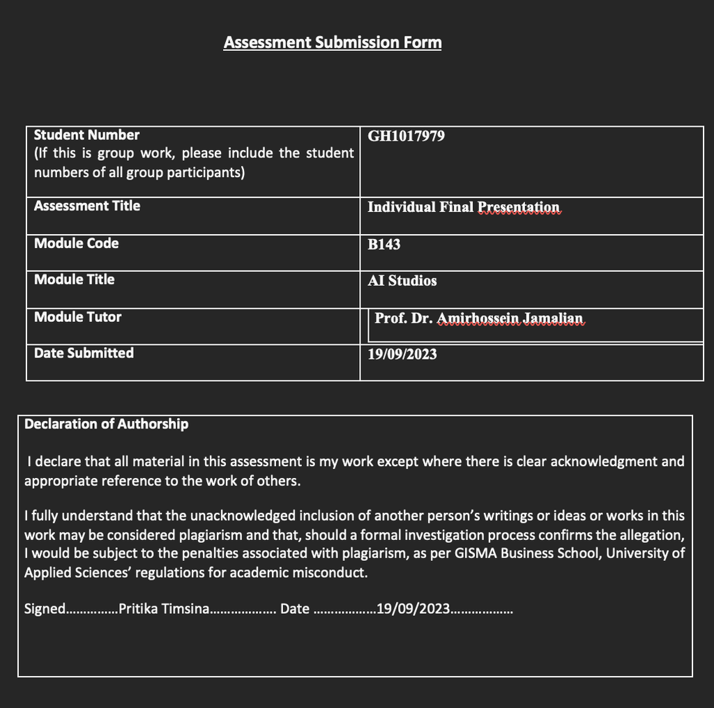

```python
image_path = "form.png"
display(Image(filename=image_path))
```